# Stan code for the seedling survival model

Masatoshi Katabuchi

June 10, 2020

In this case study I will demonstrate how seedling survival models are implemented with Stan using a simple example. Basically you can apply the same code to your seedling data. This example has reduced numbers of samples and parameters than what we are trying to do but it still takes a relatively long time to run.

# 1 Model overview

Survival (*s*) of an individual seedling *i*, of species *j*, in plot *l*, in census *t* is model as:

$$S_{ijlt} \sim Bernoulli(p_{jlt})$$

$$logit(p_{jlt}) = \boldsymbol{\beta_{j}} \cdot \boldsymbol{X} + \phi_l + \tau_t$$

where $\boldsymbol{\beta_{j}} = \left[\beta_{0j}, \beta_{1j}, \ldots, \beta_{kj} \right]$ is the vectors of coefficients at the species-level; *k* is the number of predictors for an individual seedling; $\boldsymbol{X} = \left[X_{0}, X_{1}, \ldots, X_{k} \right]$ is the predictors for an individual seedling; $\phi_l$ is a random effect for seedling plot, where $\phi_l \sim \mathcal{N}(0,\sigma_{\phi})$; and $\tau_t$ is a random effect for census, where $\phi_l \sim \mathcal{N}(0,\sigma_{\phi})$ (Note that $\cdot$ denotes dot product).

In the species-level regression, the vector of coefficients ($\beta_{0-k}$) of each species j can be assumed have a multivariate normal distribution (MVN);

$$\boldsymbol{\beta_j} \sim \mathcal{MVN}(\gamma_{n0} + \gamma_{n1} \cdot WP_j, \bf {\Sigma_{\beta}})$$

where $\gamma_{n0-1}$ are the vectors of coefficients; $WP_j$ is the water potential for species *j*; and $\bf \Sigma_{\beta}$ is the covariance matrix.

The covariance matrix $\bf \Sigma_{\beta}$ can be decomposed as ${\bf \Sigma} = {\rm diag}({\bf \sigma}){\bf \Omega}{\rm diag}({\bf \sigma}) = {\rm diag}({\bf \sigma}){\bf LL}\prime {\rm diag}({\bf \sigma})$ using a Cholesky decomposition (See [Alvarez et al. 2014](https://arxiv.org/abs/1408.4050), [Katabuchi et al. 2017](https://www.biorxiv.org/content/10.1101/116855v1.abstract) and [this post](https://stla.github.io/stlapblog/posts/stanlkjprior.html)). See the model code below for the priors.

```r
writeLines(readLines("../model/model.stan"))
```

```
## data{
##   int<lower=0> N; // number of sample
##   int<lower=1> J; // number of sp
##   int<lower=1> K; // number of tree-level preditor (i.e, CONS, HETS,...)
##   int<lower=1> L; // number of sp-level predictor (i.e., interecept and WP)
##   int<lower=1> S; // number of site
##   int<lower=1> T; // number of census
##   matrix[N, K] x; // tree-level predictor
##   matrix[J, L] u; // sp-level predictor
##   int<lower=0,upper=1> suv[N]; // 1 or 0
##   int<lower=1,upper=J> sp[N]; // integer
##   int<lower=1,upper=S> plot[N]; // integer
##   int<lower=1,upper=T> census[N]; // integer
## }
##
## parameters{
##   matrix[K, J] z;
##   vector[S] phi_raw;
##   vector[T] chi_raw;
##   matrix[L, K] gamma;
##   cholesky_factor_corr[K] L_Omega;
##   vector<lower=0,upper=pi()/2>[K] tau_unif;
##   vector<lower=0,upper=pi()/2>[2] sig_unif;
## }
##
## transformed parameters{
##   matrix[J, K] beta;
##   vector<lower=0>[K] tau;
##   vector<lower=0>[2] sig;
##   vector[S] phi;
##   vector[T] chi;
##   for (k in 1:K) tau[k] = 2.5 * tan(tau_unif[k]); // implies tau ~ cauchy(0, 2.5)
##   for (i in 1:2) sig[i] = 2.5 * tan(sig_unif[i]); // implies sig ~ cauchy(0, 2.5)
##   beta = u * gamma + (diag_pre_multiply(tau,L_Omega) * z)';
##   phi = phi_raw * sig[1];
##   chi = chi_raw * sig[2];
## }
##
## model {
##   // Hyper-priors
```

[output cut: 12 more lines]

```
##   Omega = multiply_lower_tri_self_transpose(L_Omega);
## }
##
## //generated quantities {
## //  vector[N] log_lik;
## //  vector[N] p;
## //  row_vector[K] u_gamma[J];
## //  // transformed parameters
## //  for (j in 1:J)
## //    u_gamma[j] = u[j] * gamma;
## //  for (n in 1:N) {
## //    p[n] = x[n] * beta[sp[n]] + phi[plot[n]] + tau[census[n]];
## //    log_lik[n] = bernoulli_logit_lpmf(suv[n] | p[n]);
## //  }
## // }
```

# 2 Dummy data

We generate dummy data with 20 species, 100 seedlings per species, 10 plots and 5 censuses. In total we have 2000 seedlings.

```r
library(tidyverse)
library(mvtnorm)
n_sp <- 20
sp_name <- paste0("sp", LETTERS[1:n_sp])
n_para <- 5
n_tree <- 100
n_plot <- 10
n_census <- 5
n_sample <- n_sp * n_tree
```

```r
set.seed(12345)

WP <- rnorm(n_sp, 0, 1) %>% round(3)
WP_dat <- tibble(sp = 1:n_sp, WP)
U <- cbind(Intercept = 1, WP)
rownames(U) <- sp_name
U
```

```
##     Intercept     WP
## spA         1  0.586
## spB         1  0.709
## spC         1 -0.109
## spD         1 -0.453
## spE         1  0.606
## spF         1 -1.818
## spG         1  0.630
## spH         1 -0.276
## spI         1 -0.284
## spJ         1 -0.919
## spK         1 -0.116
## spL         1  1.817
## spM         1  0.371
## spN         1  0.520
## spO         1 -0.751
## spP         1  0.817
## spQ         1 -0.886
## spR         1 -0.332
## spS         1  1.121
## spT         1  0.299
```

U is the species level predictor.

```r
gamma0 <- c(1.2, -0.4, 0.4, -0.8, 0.8)
gamma1 <- c(0, -0.4, -0.6, 0, 0)
gamma <- rbind(gamma0, gamma1)

colnames(gamma) <-  c("Intercept",
                 "CONS",
                 "HETS",
                 "CONBA",
                 "HETBA")

u_gamma <- U %*% gamma
rownames(u_gamma) <- sp_name
colnames(u_gamma) <- c("Intercept",
                 "CONS",
                 "HETS",
                 "CONBA",
                 "HETBA")

#u_gamma %>% round(3)
sig_vec <- runif(n_para, 0, 0.2)
v1 <- rnorm(n_sp, 0, sig_vec[1])
v2 <- rnorm(n_sp, v1, sig_vec[2])
v3 <- rnorm(n_sp, v2, sig_vec[3])
v4 <- rnorm(n_sp, -v3, sig_vec[4])
v5 <- rnorm(n_sp, v4, sig_vec[5])

rmat <- cbind(v1, v2, v3, v4, v5)
#create means for each column
r_mean <- matrix(data = 1, nrow = nrow(rmat)) %*% apply(rmat, 2, mean)

#creates a difference matrix
dmat <- rmat - r_mean
cmat <- (nrow(rmat)-1)^-1 * t(dmat) %*% dmat

beta <- u_gamma + rmvnorm(n_sp, rep(0, n_para), sigma = cmat)

sigma_phi <- 0.3
sigma_tau <- 0.2

phi <- rnorm(n_plot, 0, sigma_phi)
tau <- rnorm(n_census, 0, sigma_tau)
```

Some paratemers include:

- $\bf \gamma$

```r
gamma %>% t
```

```
##           gamma0 gamma1
## Intercept    1.2    0.0
## CONS        -0.4   -0.4
## HETS         0.4   -0.6
## CONBA       -0.8    0.0
## HETBA        0.8    0.0
```

```r
beta %>% round(3)
```

```
##     Intercept   CONS   HETS  CONBA HETBA
## spA     1.229 -0.618  0.089 -0.671 0.889
## spB     1.160 -0.818 -0.222 -0.382 1.239
## spC     1.045 -0.421  0.384 -0.470 1.217
## spD     1.133 -0.320  0.807 -0.981 0.537
## spE     1.200 -0.604  0.025 -0.724 0.850
## spF     0.982  0.076  1.053 -0.432 1.131
## spG     1.227 -0.674  0.011 -0.912 0.661
## spH     1.373 -0.151  0.770 -0.918 0.694
## spI     1.169 -0.497  0.294 -0.433 1.145
## spJ     1.053 -0.076  0.988 -0.596 1.029
## spK     1.332 -0.174  0.614 -0.836 0.794
## spL     1.377 -0.952 -0.404 -1.209 0.409
## spM     1.181 -0.622  0.102 -0.605 0.990
## spN     1.241 -0.496  0.056 -0.635 0.973
## spO     1.180 -0.227  0.545 -0.607 0.919
## spP     1.076 -0.833 -0.252 -0.785 0.769
## spQ     1.039 -0.196  0.735 -0.818 0.678
## spR     1.273 -0.249  0.538 -0.952 0.629
## spS     1.382 -0.718 -0.040 -1.237 0.392
## spT     1.186 -0.523 -0.010 -0.512 1.078
```

In this example, we only have 5 variables for the individual predictor, but we could add more effects (e.g., soil, season and rainfall).

```r
#plot(u_gamma, beta)
suv_mat <- matrix(numeric(n_sp * n_tree), nrow = n_sp)
X <- NULL
for (sp in 1:n_sp) {
  X0 <- matrix(rnorm(n_para * n_tree, 0, 0.2), nrow = n_para)
  X0[1,] <- 1
  suv_mat[sp, ] <- beta[sp, ] %*% X0
  X <- cbind(X, X0)
}

rownames(suv_mat) <- sp_name

p0 <- suv_mat %>%
  t %>%
  as.numeric

plot <- sample(1:n_plot, n_sample, replace = T)
census <- sample(1:n_census, n_sample, replace = T)

p00 <- p0 + phi[plot] + tau[census]

logistic <- function(z) {
  1 / (1 + exp(-z))
}

p <- logistic(p00)
suv <- rbinom(n_sample, 1, p)

dat <- tibble(suv, p = p %>% round(3), p00 = p00 %>% round(3)) %>%
 mutate(plot = plot) %>%
 mutate(census = census) %>%
 mutate(sp = rep(1:n_sp, each = n_tree)) %>%
 full_join(., WP_dat, by = "sp")

DT::datatable(dat)
```

|  | suv | p | p00 | plot | census | sp | WP |
| --- | --- | --- | --- | --- | --- | --- | --- |
| 1 | 1 | 0.748 | 1.086 | 4 | 1 | 1 | 0.586 |
| 2 | 1 | 0.804 | 1.413 | 9 | 1 | 1 | 0.586 |
| 3 | 1 | 0.618 | 0.481 | 2 | 2 | 1 | 0.586 |
| 4 | 0 | 0.62 | 0.49 | 2 | 4 | 1 | 0.586 |
| 5 | 1 | 0.846 | 1.701 | 10 | 3 | 1 | 0.586 |
| 6 | 0 | 0.81 | 1.453 | 6 | 4 | 1 | 0.586 |
| 7 | 1 | 0.812 | 1.461 | 1 | 2 | 1 | 0.586 |
| 8 | 0 | 0.753 | 1.114 | 8 | 5 | 1 | 0.586 |
| 9 | 1 | 0.869 | 1.89 | 5 | 2 | 1 | 0.586 |
| 10 | 1 | 0.55 | 0.199 | 2 | 1 | 1 | 0.586 |

[output cut: 1990 more lines]

A generated survival data set looks like this.

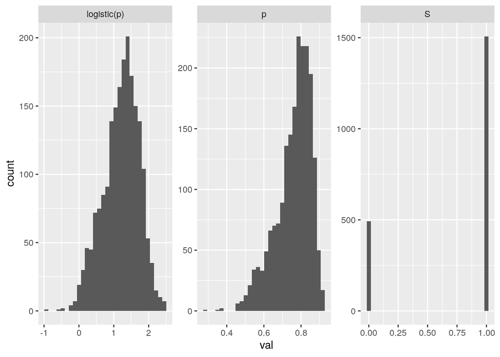

```r
hist_dat <- tibble(S = suv,
                   p = p,
                   `logistic(p)` = p00) %>%
  gather(dat, val, 1:3)

ggplot(hist_dat, aes(x = val)) +
  geom_histogram() +
  facet_wrap(~ dat, scale = "free")
```

# 3 Model

We then use the Stan to fit the data.

```r
library(rstan)
rstan::rstan_options(auto_write = TRUE)
options(mc.cores = parallel::detectCores()) # Run on multiple cores

list_dat <- list(N = nrow(dat),
                 J = n_sp,
                 K = n_para,
                 S = n_plot,
                 T = n_census,
                 L = 2,
                 suv = suv,
                 plot = plot,
                 census = census,
                 sp = dat$sp,
                 x = t(X),
                 u = U)

fit <- stan(file = "../model/model.stan",
            data = list_dat,
            iter = 1000,
            warmup = 500,
            thin = 1,
            chains =  4,
            refresh = 1000,
            control = list(adapt_delta = 0.95, max_treedepth = 20))
```

```
recompiling to avoid crashing R session
```

The resulting estimates well recovered the original values (e.g., $\bf \gamma$, $\sigma_{\tau}$ and $\sigma_{\phi}$).

```r
print(fit, pars = c("gamma", "phi", "chi", "sig"))
```

```
## Inference for Stan model: model.
## 4 chains, each with iter=1000; warmup=500; thin=1;
## post-warmup draws per chain=500, total post-warmup draws=2000.
##
##             mean se_mean   sd  2.5%   25%   50%   75% 97.5% n_eff Rhat
## gamma[1,1]  1.19    0.01 0.19  0.81  1.08  1.19  1.30  1.57   818 1.01
## gamma[1,2] -0.57    0.01 0.31 -1.16 -0.77 -0.58 -0.38  0.08  1481 1.01
## gamma[1,3]  0.16    0.01 0.31 -0.44 -0.04  0.16  0.36  0.78  1769 1.00
## gamma[1,4] -0.49    0.01 0.30 -1.08 -0.68 -0.49 -0.29  0.11  2734 1.00
## gamma[1,5]  0.93    0.01 0.29  0.37  0.73  0.94  1.12  1.51  2761 1.00
## gamma[2,1]  0.10    0.00 0.09 -0.07  0.04  0.10  0.17  0.28  1549 1.00
## gamma[2,2] -0.51    0.01 0.38 -1.27 -0.76 -0.50 -0.25  0.22  2627 1.00
## gamma[2,3] -0.75    0.01 0.39 -1.55 -1.00 -0.74 -0.50 -0.02  1660 1.00
## gamma[2,4]  0.06    0.01 0.36 -0.64 -0.18  0.06  0.28  0.77  2236 1.00
## gamma[2,5] -0.26    0.01 0.35 -0.97 -0.48 -0.27 -0.03  0.39  2426 1.00
## phi[1]      0.29    0.01 0.21 -0.10  0.15  0.28  0.42  0.72  1338 1.00
## phi[2]     -0.59    0.01 0.20 -0.99 -0.72 -0.59 -0.46 -0.20  1044 1.00
## phi[3]      0.47    0.01 0.22  0.04  0.32  0.46  0.60  0.94  1180 1.00
## phi[4]     -0.08    0.01 0.21 -0.49 -0.21 -0.08  0.05  0.32  1255 1.00
## phi[5]      0.22    0.01 0.20 -0.15  0.09  0.21  0.35  0.62  1239 1.00
## phi[6]      0.16    0.01 0.21 -0.24  0.03  0.15  0.29  0.59  1199 1.00
## phi[7]     -0.36    0.01 0.20 -0.79 -0.48 -0.35 -0.22  0.00   993 1.00
## phi[8]     -0.26    0.01 0.20 -0.69 -0.38 -0.26 -0.14  0.12  1125 1.00
## phi[9]      0.16    0.01 0.21 -0.26  0.03  0.16  0.30  0.58  1222 1.00
## phi[10]     0.04    0.01 0.20 -0.36 -0.09  0.04  0.17  0.47   992 1.01
## chi[1]     -0.06    0.00 0.12 -0.35 -0.12 -0.04  0.01  0.15  1316 1.00
## chi[2]      0.04    0.00 0.12 -0.18 -0.02  0.02  0.10  0.32  1643 1.00
## chi[3]      0.03    0.00 0.12 -0.19 -0.02  0.02  0.09  0.30  1643 1.00
## chi[4]     -0.08    0.00 0.13 -0.39 -0.15 -0.05  0.00  0.11  1051 1.00
## chi[5]      0.06    0.00 0.12 -0.15  0.00  0.04  0.12  0.35  1653 1.00
## sig[1]      0.42    0.01 0.14  0.23  0.33  0.40  0.49  0.77   740 1.00
## sig[2]      0.15    0.01 0.14  0.01  0.06  0.11  0.20  0.50   612 1.00
##
## Samples were drawn using NUTS(diag_e) at Wed Jun 10 06:23:40 2020.
## For each parameter, n_eff is a crude measure of effective sample size,
## and Rhat is the potential scale reduction factor on split chains (at
## convergence, Rhat=1).
```

```r
gamma %>% t
```

```
##           gamma0 gamma1
## Intercept    1.2    0.0
## CONS        -0.4   -0.4
## HETS         0.4   -0.6
## CONBA       -0.8    0.0
## HETBA        0.8    0.0
```

```r
save.image("../data/model.rda")
```

# 4 Diagnostic

```r
library(bayesplot)

np_cp <- nuts_params(fit)
head(np_cp)
```

```
##   Iteration     Parameter     Value Chain
## 1         1 accept_stat__ 0.9918365     1
## 2         2 accept_stat__ 0.9991058     1
## 3         3 accept_stat__ 0.9797603     1
## 4         4 accept_stat__ 0.8134520     1
## 5         5 accept_stat__ 0.9608356     1
## 6         6 accept_stat__ 0.9705514     1
```

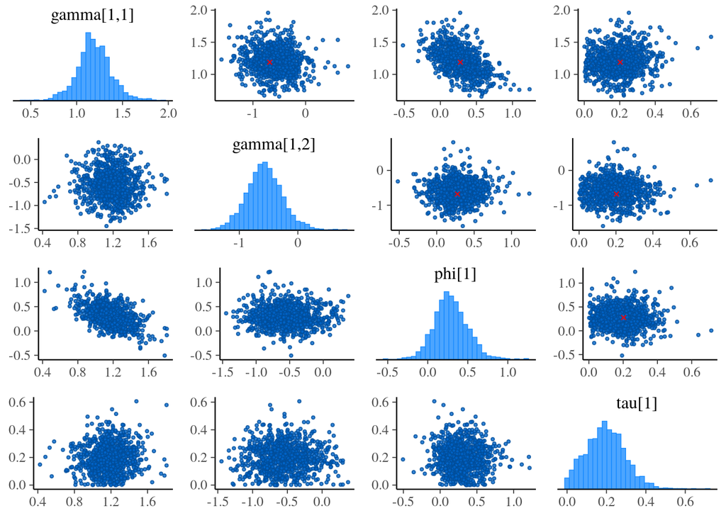

```r
color_scheme_set("brightblue")
mcmc_pairs(fit, np = np_cp, pars = c("gamma[1,1]",
                                     "gamma[1,2]",
                                     "phi[1]", "tau[1]"),
           off_diag_args = list(size = 0.75))
```